# Introducción a la estadística descriptiva

Jesús Aldana Martín

2022-03-25

# Procesado de Información

```r
datos <- read.table(file="datos_proporcionados.csv", sep=";", dec=",", header=T, stringsAsFactors = TRUE)
head(datos,20) #Primeras 20 filas.
```

```
##    Muestra Edad REst RPro Her2 Estadio NodAfec Grado Fenotipo PCR
## 1     1002 37.8    P    P    N      T2      N1     2     LumA   0
## 2     1005 45.8    P    P    N      T3      N1     2   Normal   0
## 3     1009 40.7    N    N    N      T3      N0     3    Basal   0
## 4     1011 40.8    N    N    N      T2      N1    NA    Basal   1
## 5     1016 35.5    P    P    N      T3      N1     2     LumA   0
## 6     1019 52.2    N    N    N      T4      N0     3    Basal   0
## 7     1027 38.2    N    N    I      T2      N0    NA    Basal   0
## 8     1031 54.2    I    I <NA>      T3      N1    NA     LumA   0
## 9     1034 46.6    N    N    N      T3      N3    NA    Basal   0
## 10    1035 40.8    P    P    P      T4      N3     2     LumA  NA
## 11    1037 51.1    N    N    N      T3      N1    NA    Basal   0
## 12    1038 37.8    N    N    N      T3      N1    NA    Basal   0
## 13    1041 46.6    P    P    P      T3      N3     3     LumB   0
## 14    1044 58.8    N    N    N      T3      N1    NA    Basal   0
## 15    1045 49.6    I    I <NA>      T3      N1     3    Basal   1
## 16    1049 50.4    N    N    N      T4      N1    NA    Basal   0
## 17    1050 63.2    N    N    N      T3      N1    NA    Basal   0
## 18    1054 42.8    N    N    N      T2      N1    NA    Basal   0
## 19    1055 52.8    P    P    N      T2      N0     2     LumA   0
## 20    1057 44.2    N    N    N      T4      N1     2    Basal   0
```

```r
summary(datos) #Mediante summary obtenemos un pequeño "resumen" de las variables a estudiar.
```

```
##     Muestra         Edad        REst       RPro       Her2     Estadio
##  1      :  1   Min.   :24.0   I   :  4   I   :  5   I   :  4   T0:  3
##  100    :  1   1st Qu.:42.0   N   :205   N   :258   N   :485   T1: 30
##  1002   :  1   Median :49.0   P   :297   P   :243   P   :  6   T2:255
##  1005   :  1   Mean   :49.8   NA's:  2   NA's:  2   NA's: 13   T3:145
##  1009   :  1   3rd Qu.:58.0                                    T4: 75
##  101    :  1   Max.   :75.0
##  (Other):502
##  NodAfec      Grado         Fenotipo        PCR
##  N0:157   Min.   :1.000   Basal :189   Min.   :0.0000
##  N1:244   1st Qu.:2.000   Her2  : 37   1st Qu.:0.0000
##  N2: 66   Median :3.000   LumA  :160   Median :0.0000
##  N3: 41   Mean   :2.482   LumB  : 78   Mean   :0.2029
##           3rd Qu.:3.000   Normal: 44   3rd Qu.:0.0000
##           Max.   :3.000                Max.   :1.0000
##           NA's   :37                   NA's   :20
```

# Función MODA

Función para hallar la Moda de la columna indicada:

```r
statistic_mode <- function(x){
    return(names(which.max(table(x))))
}
```

```r
table(datos$REst)
```

```
##
##   I   N   P
##   4 205 297
```

```r
table(datos$RPro)
```

```
##
##   I   N   P
##   5 258 243
```

```r
table(datos$Her2)
```

```
##
##   I   N   P
##   4 485   6
```

```r
table(datos$Grado)
```

```
##
##   1   2   3
##  32 180 259
```

```r
grados_integer <- as.integer(na.omit(datos$Grado))
```

Gracias a esta vista general de los datos para poner pasar al analisis univariante primero debemos de corregir los datos perdidos. Los datos proporcionados tienen tanto NaN como en algunas variables categoricas “I” de indeterminado. Para solucionar estudiaré los datos eliminando directamente los atributos perdidos obteniendo directamente los valores de estudio y también sustituire los valores perdidos por la media o moda de la columna y mantener la misma cantidad de datos que se nos proporciona para el estudio.

```r
#Columnas con valores indeterminados, transformo los valores indeterminados en NA
datos$REst[datos$REst == "I"] <- NA
datos$RPro[datos$RPro == "I"] <- NA
datos$Her2[datos$Her2 == "I"] <- NA
```

```r
#Calculo la moda de cada columna y la sustituyo en los valores perdidos.
modaRest <- statistic_mode(na.omit(datos$REst))
modaRPro <- statistic_mode(na.omit(datos$RPro))
modaHer2 <- statistic_mode(na.omit(datos$Her2))
modaPCR <- statistic_mode(na.omit(datos$PCR))

datos$REst[is.na(datos$REst)] <- modaRest
datos$RPro[is.na(datos$RPro)] <- modaRPro
datos$Her2[is.na(datos$Her2)] <- modaHer2
datos$PCR[is.na(datos$PCR)] <- modaPCR

#La columna Grado aunque sea numérica sustituyo los valores perdidos por la moda también ya que esta solo se expresa como 1, 2 o 3 y la media daría un valor double.

modaGrado <- statistic_mode(na.omit(datos$Grado))
datos$Grado[is.na(datos$Grado)] <- modaGrado
```

```r
#Tablas con los valores sustituidos
table(datos$REst)
```

```
##
##   I   N   P
##   0 205 303
```

```r
table(datos$RPro)
```

```
##
##   I   N   P
##   0 265 243
```

```r
table(datos$Her2)
```

```
##
##   I   N   P
##   0 502   6
```

```r
table(datos$Grado)
```

```
##
##   1   2   3
##  32 180 296
```

```r
grados_sustituidos <- as.integer(datos$Grado)
```

#Análisis Univariante.

Análisis univariante respecto a la PCR, en este apartado el objetivo es definir, resumir y analizar el ptrón presente en ellos. Explorando cada variable por separado. Los más faciles de indentificar son la Tendencia central (media,moda,mediana), Dispersión(rango, varianza) y Desviación Estándar. Para ello representaremos las variables en gráficos de barras, histogramas etc..

```r
mean(grados_integer) #Media eliminando los valores NaN.
```

```
## [1] 2.481953
```

```r
mean(grados_sustituidos)#Media sustituyendo los valores perdidos por la moda.
```

```
## [1] 2.519685
```

```r
edad <- datos$Edad
var(edad)
```

```
## [1] 109.4768
```

```r
sd(edad)
```

```
## [1] 10.46311
```

```r
median(edad)
```

```
## [1] 49
```

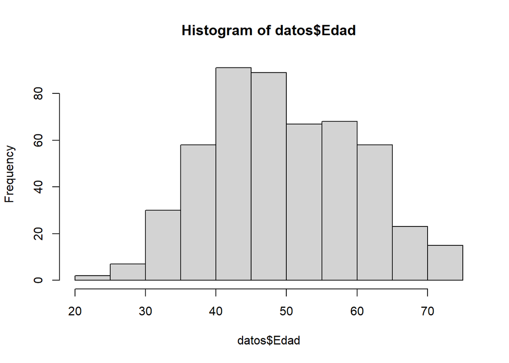

```r
hist(datos$Edad) #Histograma Edades
```

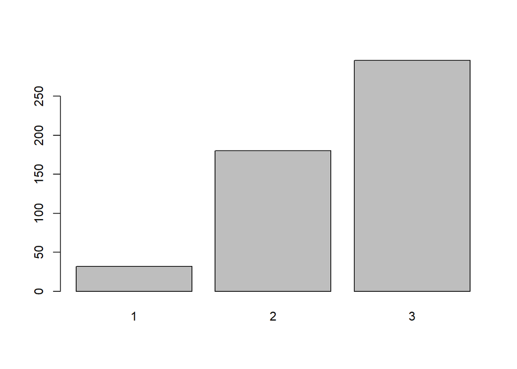

```r
barplot(table(datos$Grado))
```

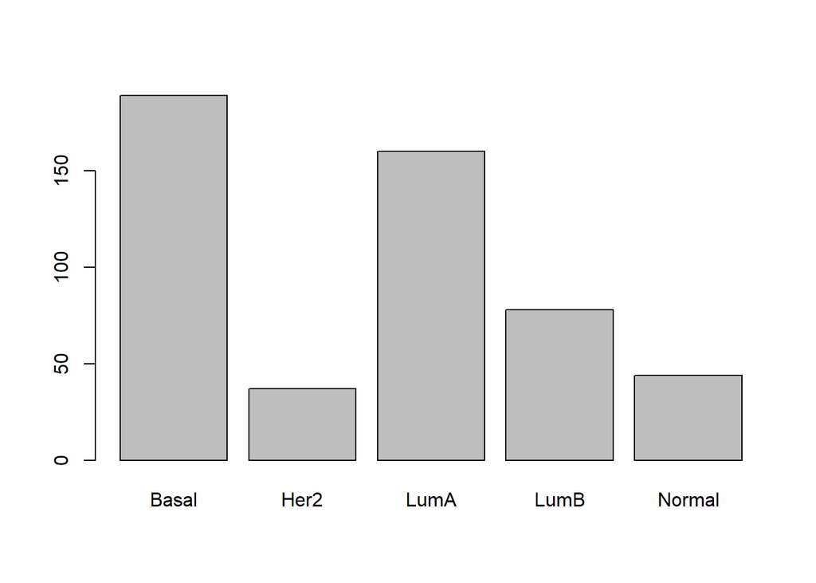

```r
barplot(table(datos$Fenotipo))
```

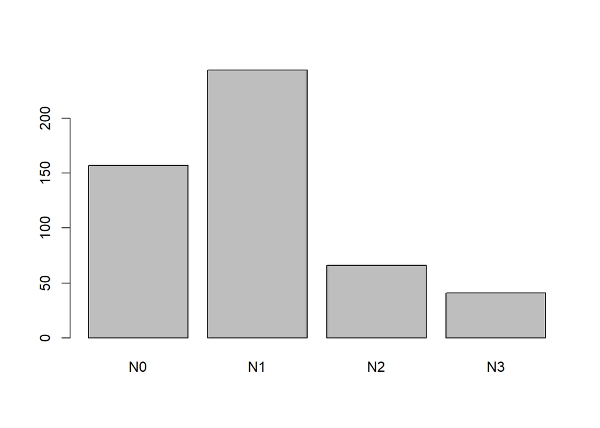

```r
barplot(table(datos$NodAfec))
```

#Análisis Bivariante respecto de la PCR, mediante test estádisticos.

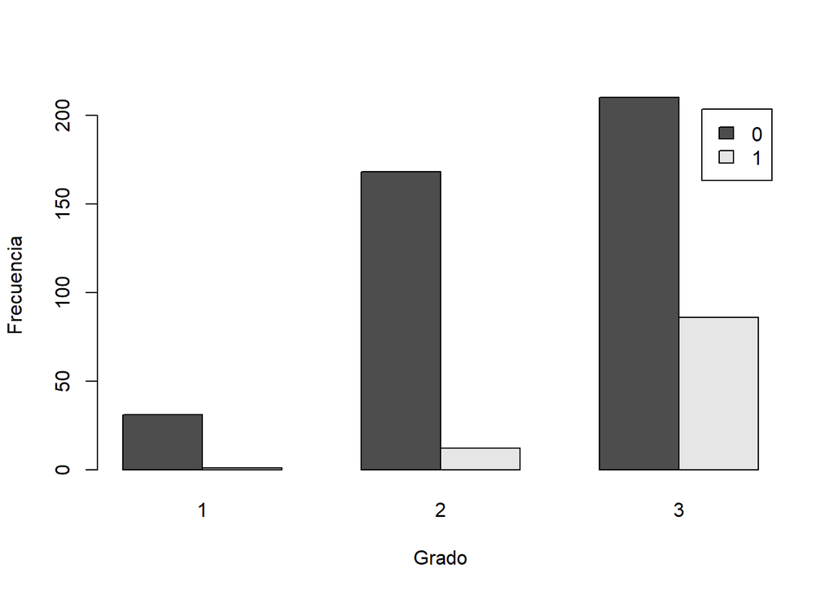

```r
#Solo representando la PCR respecto al GRADO ya podemos observar como a mayor sea el grado del tumor mayor posibilidad de Metástasis(poco menos de la mitad de los pacientes)
barplot(table(datos$PCR, datos$Grado), beside = TRUE, legend.text = TRUE, ylab = "Frecuencia", xlab = "Grado")
```

```r
#Para poder comparar tambien la edad con el resto de variables inserto la edad en un vector y lo separo por intervalos
datos$Edad_categorica <-  cut(datos$Edad, breaks=c(0,40,60,max(datos$Edad)))
datos$Edad_categorica[1:10] #Expreso los 10 primeros intervalos para comprobar que se ha modificado correctamente.
```

```
##  [1] (0,40]  (40,60] (40,60] (40,60] (0,40]  (40,60] (0,40]  (40,60] (40,60]
## [10] (40,60]
## Levels: (0,40] (40,60] (60,75]
```

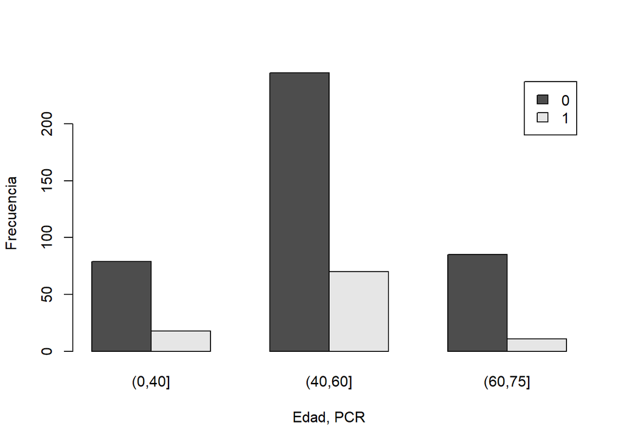

```r
#Al comparar las variables Grado y PCR respecto a la edad (las que mas influyen en la mortalidad del paciente) obtenemos los siguientes grafos , sin embargo, esta información es poco útil ya que la media de edades de nuestro archivo es de 49.80492 por tanto hay mayor frecuencia de metástasis y de cada grado de tumor para el intervalo de edades[40,60] Lo único que podemos sacar en claro es que esa franja de edad es la más común a la hora de desarrollar un tumor.

barplot(table(datos$PCR,datos$Edad_categorica), beside = TRUE, legend.text = TRUE, ylab = "Frecuencia", xlab = "Edad, PCR")
```

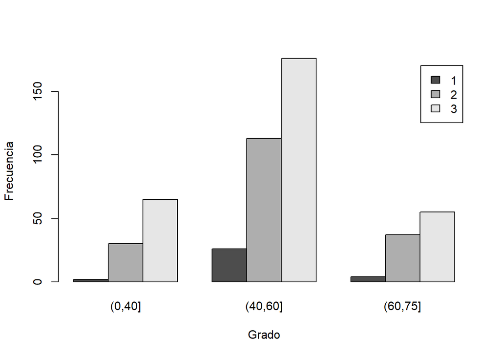

```r
barplot(table(datos$Grado, datos$Edad_categorica), beside = TRUE, legend.text = TRUE, ylab = "Frecuencia", xlab = "Grado")
```

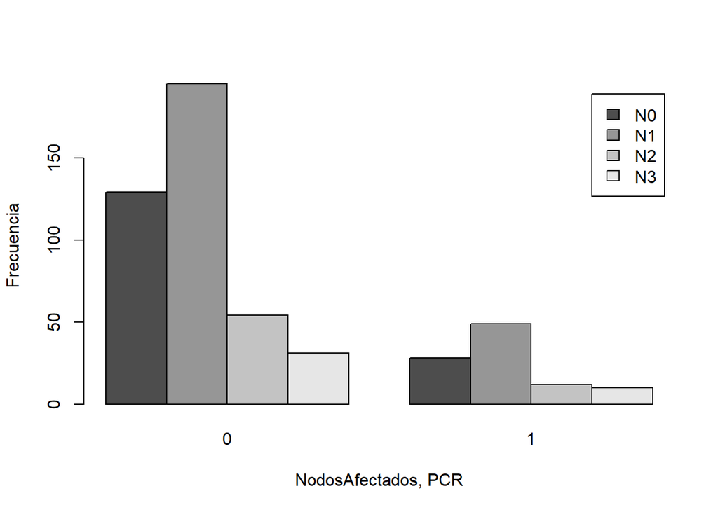

```r
# Barplot NodosAfectados respecto a PCR
barplot(table(datos$NodAfec, datos$PCR), beside = TRUE, legend.text = TRUE, ylab = "Frecuencia", xlab = "NodosAfectados, PCR")
```

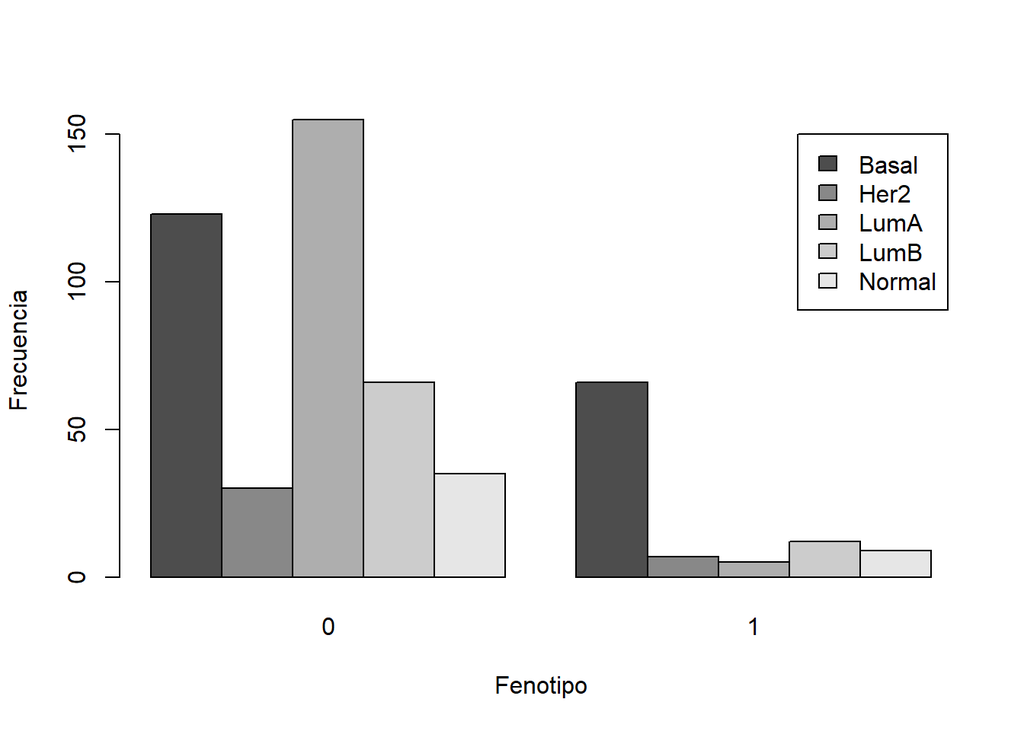

```r
# Observamos que de expresar el fenotipo Basal lo probabilidad de metástasis aumenta considerablemente.
barplot(table(datos$Fenotipo, datos$PCR), beside = TRUE, legend.text = TRUE, ylab = "Frecuencia", xlab = "Fenotipo")
```

```r
test_estadistico <- function(columna){
  if(is.numeric(columna)){
    ret <- t.test(PCR ~ columna, data = datos)
  }else{
   tablaContingencia <- xtabs(~ PCR + columna, data = datos)
    if(ncol(tablaContingencia) <= 3 & nrow(tablaContingencia) == 2){
      ret<- fisher.test(tablaContingencia)
    }else{
      ret <- chisq.test(tablaContingencia)
    }

  }
  return(ret)
}
```

```r
test_estadistico(datos$Edad_categorica)
```

```
##
##  Fisher's Exact Test for Count Data
##
## data:  tablaContingencia
## p-value = 0.0577
## alternative hypothesis: two.sided
```

```r
test_estadistico(datos$REst)
```

```
##
##  Fisher's Exact Test for Count Data
##
## data:  tablaContingencia
## p-value = 2.813e-10
## alternative hypothesis: two.sided
```

```r
test_estadistico(datos$RPro)
```

```
##
##  Fisher's Exact Test for Count Data
##
## data:  tablaContingencia
## p-value = 1.863e-06
## alternative hypothesis: two.sided
```

```r
test_estadistico(datos$Her2)
```

```
##
##  Fisher's Exact Test for Count Data
##
## data:  tablaContingencia
## p-value = 0.332
## alternative hypothesis: two.sided
```

```r
test_estadistico(datos$Estadio)
```

```
##
##  Pearson's Chi-squared test
##
## data:  tablaContingencia
## X-squared = 3.7099, df = 4, p-value = 0.4467
```

```r
test_estadistico(datos$NodAfec)
```

```
##
##  Pearson's Chi-squared test
##
## data:  tablaContingencia
## X-squared = 1.0282, df = 3, p-value = 0.7944
```

```r
test_estadistico(datos$Grado)
```

```
##
##  Fisher's Exact Test for Count Data
##
## data:  tablaContingencia
## p-value = 1.139e-10
## alternative hypothesis: two.sided
```

#Análisis Multivariante

```r
library(MASS)

datos_sinMuestra <- datos[,-1]
regresionLogistica <- glm(PCR == 1 ~ ., data = datos_sinMuestra, family = binomial("logit"))
summary(regresionLogistica)
```

```
##
## Call:
## glm(formula = PCR == 1 ~ ., family = binomial("logit"), data = datos_sinMuestra)
##
## Deviance Residuals:
##     Min       1Q   Median       3Q      Max
## -1.2729  -0.7283  -0.3388  -0.1684   2.9445
##
## Coefficients:
##                        Estimate Std. Error z value Pr(>|z|)
## (Intercept)            -0.62667    2.08669  -0.300  0.76394
## Edad                   -0.02689    0.02430  -1.106  0.26861
## REstP                  -0.39476    0.37917  -1.041  0.29783
## RProP                   0.01616    0.35567   0.045  0.96376
## Her2P                   0.56896    1.01671   0.560  0.57575
## EstadioT1              -0.59645    1.46613  -0.407  0.68414
## EstadioT2              -0.67140    1.38331  -0.485  0.62743
## EstadioT3              -0.82947    1.38951  -0.597  0.55054
## EstadioT4              -1.43148    1.41202  -1.014  0.31069
## NodAfecN1              -0.11076    0.29484  -0.376  0.70718
## NodAfecN2              -0.24242    0.43158  -0.562  0.57432
## NodAfecN3              -0.06724    0.48178  -0.140  0.88900
## Grado2                  0.72444    1.11575   0.649  0.51615
## Grado3                  1.74449    1.10260   1.582  0.11361
## FenotipoHer2           -0.47509    0.48591  -0.978  0.32820
## FenotipoLumA           -1.96483    0.60327  -3.257  0.00113 **
## FenotipoLumB           -0.60862    0.46642  -1.305  0.19194
## FenotipoNormal         -0.19629    0.45850  -0.428  0.66857
## Edad_categorica(40,60]  0.93240    0.46590   2.001  0.04536 *
## Edad_categorica(60,75]  0.32343    0.83375   0.388  0.69807
## ---
## Signif. codes:  0 '***' 0.001 '**' 0.01 '*' 0.05 '.' 0.1 ' ' 1
##
## (Dispersion parameter for binomial family taken to be 1)
##
##     Null deviance: 501.12  on 507  degrees of freedom
## Residual deviance: 408.27  on 488  degrees of freedom
## AIC: 448.27
##
## Number of Fisher Scoring iterations: 6
```

Ahora mediante el método stepwise backwards obtenemos como resultado 6 iteraciones, y procedo a realizar 4 predicciones de R para los siguientes valores. En cada una comprobe un fenotipo diferente pues era el atributo que la regresión logistica me marcaba observamos como el fenotipo con mayor probabilidad de aparecer para los PCR = 1 es el BASAL.

```r
regresionLogistica_backwards <- stepAIC(regresionLogistica, direction = "backward")
```

```
## Start:  AIC=448.27
## PCR == 1 ~ Edad + REst + RPro + Her2 + Estadio + NodAfec + Grado +
##     Fenotipo + Edad_categorica
##
##                   Df Deviance    AIC
## - NodAfec          3   408.61 442.61
## - Estadio          4   412.31 444.31
## - RPro             1   408.27 446.27
## - Her2             1   408.58 446.58
## - REst             1   409.37 447.37
## - Edad             1   409.51 447.51
## <none>                 408.27 448.27
## - Fenotipo         4   421.23 453.23
## - Edad_categorica  2   417.36 453.36
## - Grado            2   418.51 454.51
##
## Step:  AIC=442.61
## PCR == 1 ~ Edad + REst + RPro + Her2 + Estadio + Grado + Fenotipo +
##     Edad_categorica
##
##                   Df Deviance    AIC
## - Estadio          4   413.43 439.43
## - RPro             1   408.62 440.62
## - Her2             1   408.91 440.91
## - REst             1   409.72 441.72
## - Edad             1   409.77 441.77
## <none>                 408.61 442.61
## - Fenotipo         4   421.49 447.49
## - Edad_categorica  2   417.93 447.93
## - Grado            2   418.66 448.66
##
## Step:  AIC=439.43
## PCR == 1 ~ Edad + REst + RPro + Her2 + Grado + Fenotipo + Edad_categorica
##
##                   Df Deviance    AIC
## - RPro             1   413.46 437.46
## - Her2             1   413.72 437.72
## - REst             1   414.68 438.68
## - Edad             1   414.89 438.89
## <none>                 413.43 439.43
```

[output cut: 30 more lines]

```
##                   Df Deviance    AIC
## - Edad             1   416.69 434.69
## <none>                 415.10 435.10
## - Edad_categorica  2   424.33 440.33
## - Grado            2   425.98 441.98
## - Fenotipo         4   444.89 456.89
##
## Step:  AIC=434.69
## PCR == 1 ~ Grado + Fenotipo + Edad_categorica
##
##                   Df Deviance    AIC
## <none>                 416.69 434.69
## - Edad_categorica  2   426.01 440.01
## - Grado            2   427.74 441.74
## - Fenotipo         4   446.14 456.14
```

```r
summary(regresionLogistica_backwards)
```

```
##
## Call:
## glm(formula = PCR == 1 ~ Grado + Fenotipo + Edad_categorica,
##     family = binomial("logit"), data = datos_sinMuestra)
##
## Deviance Residuals:
##     Min       1Q   Median       3Q      Max
## -1.0808  -0.7455  -0.4036  -0.1669   2.9262
##
## Coefficients:
##                        Estimate Std. Error z value Pr(>|z|)
## (Intercept)             -2.6027     1.1335  -2.296   0.0217 *
## Grado2                   0.7871     1.1059   0.712   0.4767
## Grado3                   1.8007     1.0909   1.651   0.0988 .
## FenotipoHer2            -0.7479     0.4595  -1.628   0.1036
## FenotipoLumA            -2.2352     0.5150  -4.340 1.42e-05 ***
## FenotipoLumB            -0.9024     0.3638  -2.480   0.0131 *
## FenotipoNormal          -0.3363     0.4380  -0.768   0.4426
## Edad_categorica(40,60]   0.5706     0.3176   1.796   0.0724 .
## Edad_categorica(60,75]  -0.3916     0.4347  -0.901   0.3677
## ---
## Signif. codes:  0 '***' 0.001 '**' 0.01 '*' 0.05 '.' 0.1 ' ' 1
##
## (Dispersion parameter for binomial family taken to be 1)
##
##     Null deviance: 501.12  on 507  degrees of freedom
## Residual deviance: 416.69  on 499  degrees of freedom
## AIC: 434.69
##
## Number of Fisher Scoring iterations: 6
```

```r
predict(regresionLogistica_backwards, newdata = data.frame(PCR = 1, RPro = "N", Her2 = "P", REst = "P", Estadio = "T1", Grado = "2",NodAfec = "N2" ,Fenotipo = "Normal", Edad_categorica ="(40,60]"), type = "response")
```

```
##         1
## 0.1705983
```

```r
predict(regresionLogistica_backwards, newdata = data.frame(PCR = 1, RPro = "N", Her2 = "P", REst = "P", Estadio = "T1", Grado = "2",NodAfec = "N2" ,Fenotipo = "LumA", Edad_categorica ="(40,60]"), type = "response")
```

```
##          1
## 0.02988038
```

```r
predict(regresionLogistica_backwards, newdata = data.frame(PCR = 1, RPro = "N", Her2 = "P", REst = "P", Estadio = "T1", Grado = "2",NodAfec = "N2" ,Fenotipo = "LumB", Edad_categorica ="(40,60]"), type = "response")
```

```
##         1
## 0.1045741
```

```r
predict(regresionLogistica_backwards, newdata = data.frame(PCR = 1, RPro = "N", Her2 = "P", REst = "P", Estadio = "T1", Grado = "2",NodAfec = "N2" ,Fenotipo = "Basal", Edad_categorica ="(40,60]"), type = "response")
```

```
##         1
## 0.2235587
```

```r
mod.lin <- lm(PCR == "1"~ Edad_categorica + Fenotipo, data = datos)
summary(mod.lin)
```

```
##
## Call:
## lm(formula = PCR == "1" ~ Edad_categorica + Fenotipo, data = datos)
##
## Residuals:
##      Min       1Q   Median       3Q      Max
## -0.38859 -0.23569 -0.06970  0.00881  1.00881
##
## Coefficients:
##                        Estimate Std. Error t value Pr(>|t|)
## (Intercept)             0.31659    0.04169   7.595 1.52e-13 ***
## Edad_categorica(40,60]  0.07200    0.04365   1.649 0.099674 .
## Edad_categorica(60,75] -0.04528    0.05397  -0.839 0.401918
## FenotipoHer2           -0.16626    0.06730  -2.470 0.013830 *
## FenotipoLumA           -0.32540    0.04023  -8.088 4.61e-15 ***
## FenotipoLumB           -0.19510    0.05038  -3.873 0.000122 ***
## FenotipoNormal         -0.15290    0.06261  -2.442 0.014943 *
## ---
## Signif. codes:  0 '***' 0.001 '**' 0.01 '*' 0.05 '.' 0.1 ' ' 1
##
## Residual standard error: 0.3728 on 501 degrees of freedom
## Multiple R-squared:  0.1265, Adjusted R-squared:  0.116
## F-statistic: 12.09 on 6 and 501 DF,  p-value: 1.038e-12
```

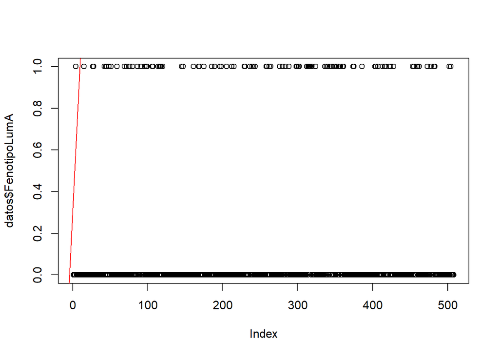

```r
plot(datos$PCR == 1, datos$FenotipoLumA)
abline(mod.lin, col = "red")
```